```python
#Datenaufbereitung
import pandas as pd
import numpy as np
#Visualisierung
import matplotlib.pyplot as plt
import seaborn as sns
import plotly.express as px
import plotly.graph_objects as go
import ipywidgets as widgets
from IPython.display import display
#Quellen
import re
from pybtex.database import parse_file
#Statistik
from sinfo import sinfo
import sys
```

# Kinderbetreuung in München

**Author**: Dino Dervisevic

**Datum**: 22.06.2024

# Aufgabe 1 Hypothesengenerierung & Datenbeschaffung

## Beschreibung Kinderbetreuung

Kinderbetreuung bezeichnet die Beaufsichtigung und Betreuung von Kindern durch andere Personen als die Eltern oder Erziehungsberechtigten. Dies kann in verschiedenen Einrichtungen wie Kindertagesstätten, bei Tagesmüttern oder durch Babysitter erfolgen. Dabei wird darauf geachtet, dass die Kinder sicher sind, spielen, lernen und gut versorgt werden, während die Eltern arbeiten oder anderweitig beschäftigt sind.

## SDG Auswahl

### SDG 10 – Reduce inequality within and among countries[1]

Das 10. Ziel für nachhaltige Entwicklung (SDG) lautet "Weniger Ungleichheiten". Es zielt darauf ab, Ungleichheiten innerhalb und zwischen Ländern zu verringern. Dieses Ziel fördert Chancengleichheit für alle Menschen, unabhängig von ihrem Wohnort, Geschlecht oder wirtschaftlichen Hintergrund.

Es geht darum, die Diskrepanz zwischen Wohlhabenden und Armen sowie zwischen verschiedenen sozialen Gruppen zu minimieren. Dies umfasst Maßnahmen zur Reduktion von Einkommensungleichheiten, zur Verbesserung des Zugangs zu Bildung und Gesundheitsversorgung und zur Beseitigung von Diskriminierung.

Die **Bedeutung** dieses Ziels liegt in der Schaffung einer gerechteren und integrativeren Gesellschaft. Wenn Ungleichheiten abgebaut werden, können mehr Menschen ihr volles Potenzial entfalten, was zu einem harmonischeren und nachhaltigeren globalen Wachstum führt.

## Arbeitshypothese

Kinder, deren Familiensprache nicht Deutsch ist, haben einen eingeschränkten Zugang zu Kinderbetreuung, was zur Ungleichheit beiträgt und die Ziele des Sustainable Development Goal (SDG) 10 zur Reduzierung von Ungleichheiten behindert.

**Auswirkung auf die Kinder:** Kinder mit eingeschränktem Zugang zu hochwertiger Kinderbetreuung können in ihrer sprachlichen, kognitiven und sozialen Entwicklung benachteiligt werden. Dies kann langfristig zu schlechteren schulischen Leistungen und Integrationsschwierigkeiten führen.

**Auswirkung auf die Familie:** Familien könnten finanzielle Belastungen und berufliche Nachteile erfahren, wenn sie keine erschwingliche Betreuung finden. Dies erhöht den Stress und beeinträchtigt das Wohlbefinden der gesamten Familie, was die Ungleichheiten weiter verstärkt.

## Datenquellen

Alle genannten Datensätze stammen von der Open Data Seite der Stadt München.

### 1. Indikatorenatlas: Kinderbetreuung - Altersgruppen[3]

**Erklärung:** Dieser Datensatz enthält Informationen über die Verteilung und Nutzung von Kinderbetreuungseinrichtungen in verschiedenen Altersgruppen. Er bietet Einblicke in die allgemeine Verfügbarkeit und Inanspruchnahme von Betreuungsangeboten für alle Kinder.

**Begründung der Auswahl:** Mit diesem Datensatz kann der allgemeine Zugang zu Kinderbetreuung in verschiedenen Altersgruppen analysiert werden. Er dient als Basis, um Unterschiede zwischen nicht-deutschen und deutschen Kindern herauszuarbeiten.

### 2. Indikatorenatlas: Kinderbetreuung - Altersgruppen Familiensprache nichtdeutsch[4]

**Erklärung:** Dieser Datensatz zeigt die Nutzung von Kinderbetreuungseinrichtungen durch Kinder, deren Familiensprache nicht Deutsch ist.

**Begründung der Auswahl:** Dieser Datensatz ermöglicht es, den Zugang zu Kinderbetreuung für nicht-deutsche Kinder direkt zu untersuchen und mit den allgemeinen Daten aus dem ersten Datensatz zu vergleichen. Unterschiede in der Inanspruchnahme können so identifiziert und analysiert werden.

### 3. Indikatorenatlas: Bevölkerung - Migrationshintergrund - Kinder[2]

**Erklärung:** Dieser Datensatz enthält Informationen über die Anzahl und den Anteil von Kindern mit Migrationshintergrund in der Bevölkerung.

**Begründung der Auswahl:** Dieser Datensatz hilft dabei, die demografische Basis zu verstehen und die Bevölkerungsstruktur zu analysieren. Dadurch lässt sich feststellen, wie groß die Gruppe der Kinder mit Migrationshintergrund ist und ob diese Gruppe im Vergleich zu ihrer Größe in der Nutzung von Kinderbetreuung unterrepräsentiert ist.

### Vergleich der Datensätze:

Durch den Vergleich dieser Datensätze können Unterschiede im Zugang zur Kinderbetreuung zwischen deutschen und nicht-deutschen Kindern sowie Kindern mit Migrationshintergrund identifiziert werden. Dies ermöglicht eine genaue Analyse der Hypothese und zeigt, ob die beschränkte Verfügbarkeit von Kinderbetreuung für nicht-deutsche Kinder zur Ungleichheit beiträgt.

# Aufgabe 2 Datenaufbereitung

## Kinderbetreuung Altersgruppen

```python
# Daten einlesen
df_altersgruppen = pd.read_csv('data/kinderbetreuung_altersgruppen.csv')
# Anzeige der ersten 5 Zeilen
df_altersgruppen.head()
```

|  | Indikator | Ausprägung | Jahr | Raumbezug | Indikatorwert | Basiswert.1 | Basiswert.2 | Name.Basiswert.1 | Name.Basiswert.2 |
| --- | --- | --- | --- | --- | --- | --- | --- | --- | --- |
| 0 | Altersgruppen | bis 2 Jahre | 2022 | Stadt München | 20.3 | 17126 | 84333 | betreute Kinder (bis 2 Jahre) | betreute Kinder (insgesamt) |
| 1 | Altersgruppen | bis 2 Jahre | 2022 | 01 Altstadt - Lehel | 24.1 | 236 | 980 | betreute Kinder (bis 2 Jahre) | betreute Kinder (insgesamt) |
| 2 | Altersgruppen | bis 2 Jahre | 2022 | 02 Ludwigsvorstadt - Isarvorstadt | 26.3 | 653 | 2482 | betreute Kinder (bis 2 Jahre) | betreute Kinder (insgesamt) |
| 3 | Altersgruppen | bis 2 Jahre | 2022 | 03 Maxvorstadt | 27.3 | 745 | 2727 | betreute Kinder (bis 2 Jahre) | betreute Kinder (insgesamt) |
| 4 | Altersgruppen | bis 2 Jahre | 2022 | 04 Schwabing - West | 24.1 | 549 | 2278 | betreute Kinder (bis 2 Jahre) | betreute Kinder (insgesamt) |

```python
# info dient dazu, einen Überblick über die Daten zu bekommen
df_altersgruppen.info()
```

```
<class 'pandas.core.frame.DataFrame'>
RangeIndex: 1248 entries, 0 to 1247
Data columns (total 9 columns):
 #   Column            Non-Null Count  Dtype
---  ------            --------------  -----
 0   Indikator         1248 non-null   object
 1   Ausprägung        1248 non-null   object
 2   Jahr              1248 non-null   int64
 3   Raumbezug         1248 non-null   object
 4   Indikatorwert     1248 non-null   float64
 5   Basiswert.1       1248 non-null   int64
 6   Basiswert.2       1248 non-null   int64
 7   Name.Basiswert.1  1248 non-null   object
 8   Name.Basiswert.2  1248 non-null   object
dtypes: float64(1), int64(3), object(5)
memory usage: 87.9+ KB
```

### Kategorisierung der Variablen

1. **Indikator (kategorial)**
   - Unterschiedliche Messgrößen, keine Reihenfolge
2. **Ausprägung (kategorial)**
   - Verschiedene Kategorien innerhalb eines Indikators
3. **Jahr (metrisch)**
   - Zeitvariable, kontinuierlich und quantitative Unterschiede
4. **Raumbezug (kategorial)**
   - Geografische oder administrative Einheiten
5. **Indikatorwert (metrisch)**
   - Numerische Messgröße, kontinuierlich
6. **Basiswert.1 (metrisch)**
   - Numerische Basiswert, kontinuierlich
7. **Basiswert.2 (metrisch)**
   - Numerische Basiswert, kontinuierlich
8. **Name.Basiswert.1 (kategorial)**
   - Kategorie des ersten Basiswerts
9. **Name.Basiswert.2 (kategorial)**
   - Kategorie des zweiten Basiswerts

```python
# Kodierung der Variablen

#astype() dient dazu, den Datentyp zu ändern
df_altersgruppen['Indikator'] = df_altersgruppen['Indikator'].astype('category')
df_altersgruppen['Ausprägung'] = df_altersgruppen['Ausprägung'].astype('category')
#df_altersgruppen['Jahr'] = df_altersgruppen['Jahr'].astype('int64')
df_altersgruppen['Raumbezug'] = df_altersgruppen['Raumbezug'].astype('category')
#df_altersgruppen['Indikatorwert'] = df_altersgruppen['Indikatorwert'].astype('float64')
#df_altersgruppen['Basiswert.1'] = df_altersgruppen['Basiswert.1'].astype('int64')
#df_altersgruppen['Basiswert.2'] = df_altersgruppen['Basiswert.2'].astype('int64')
df_altersgruppen['Name.Basiswert.1'] = df_altersgruppen['Name.Basiswert.1'].astype('category')
df_altersgruppen['Name.Basiswert.2'] = df_altersgruppen['Name.Basiswert.2'].astype('category')

df_altersgruppen.info()
```

```
<class 'pandas.core.frame.DataFrame'>
RangeIndex: 1248 entries, 0 to 1247
Data columns (total 9 columns):
 #   Column            Non-Null Count  Dtype
---  ------            --------------  -----
 0   Indikator         1248 non-null   category
 1   Ausprägung        1248 non-null   category
 2   Jahr              1248 non-null   int64
 3   Raumbezug         1248 non-null   category
 4   Indikatorwert     1248 non-null   float64
 5   Basiswert.1       1248 non-null   int64
 6   Basiswert.2       1248 non-null   int64
 7   Name.Basiswert.1  1248 non-null   category
 8   Name.Basiswert.2  1248 non-null   category
dtypes: category(5), float64(1), int64(3)
memory usage: 47.0 KB
```

### Fehlende Werte

Der DataFrame hat keine fehlenden Werte, da alle Spalten 1248 Nicht-Null-Werte haben.

### Wertebereiche und Kategorien

### Ausprägung

**Kontext**: Die Spalte “Ausprägung” im DataFrame df_altersgruppen kategorisiert die Daten nach Altersgruppen. Um sicherzustellen, dass die Altersgruppen korrekt und konsistent repräsentiert sind, wird die Häufigkeit jeder Altersgruppe überprüft.

```python
# value_counts() zählt die Häufigkeit der Ausprägungen
df_altersgruppen["Ausprägung"].value_counts()
```

```
Ausprägung
3 bis 7 Jahre (ohne Schulkinder)    416
5 bis 13 Jahre (Schulkinder)        416
bis 2 Jahre                         416
Name: count, dtype: int64
```

**Ergebnis**: Die Ausgabe zeigt, dass jede der drei Altersgruppen exakt 416 Einträge hat. Dies deutet darauf hin, dass die Daten gleichmäßig über die Altersgruppen verteilt sind und keine Altersgruppe über- oder unterrepräsentiert ist.

### Jahr

**Kontext**: Die Spalte “Jahr” im DataFrame df_altersgruppen repräsentiert verschiedene Jahre, für die Daten zur Kinderbetreuung erhoben wurden. Die Überprüfung der Häufigkeit jedes Jahres hilft dabei zu verstehen, wie die Daten über die verschiedenen Jahre verteilt sind.

```python
df_altersgruppen["Jahr"].value_counts()
```

```
Jahr
2022    78
2021    78
2020    78
2019    78
2018    78
2017    78
2016    78
2015    78
2014    78
2013    78
2012    78
2011    78
2010    78
2009    78
2008    78
2007    78
Name: count, dtype: int64
```

**Ergebnis**: Die Ausgabe zeigt, dass jedes Jahr von 2007 bis 2022 genau 78 Einträge hat. Dies deutet darauf hin, dass die Daten gleichmäßig über die Jahre verteilt sind.

### Raumbezug

**Kontext**: Die Spalte “Raumbezug” im DataFrame df_altersgruppen repräsentiert verschiedene Stadtteile von München, für die Daten zur Kinderbetreuung erhoben wurden. Die Überprüfung der Häufigkeit jeder Einheit hilft dabei zu verstehen, wie die Daten über die verschiedenen Stadtteile verteilt sind.

```python
df_altersgruppen["Raumbezug"].value_counts()
```

```
Raumbezug
01 Altstadt - Lehel                                                  48
02 Ludwigsvorstadt - Isarvorstadt                                    48
25 Laim                                                              48
24 Feldmoching - Hasenbergl                                          48
23 Allach - Untermenzing                                             48
22 Aubing - Lochhausen - Langwied                                    48
21 Pasing - Obermenzing                                              48
20 Hadern                                                            48
19 Thalkirchen - Obersendling - Forstenried - Fürstenried - Solln    48
18 Untergiesing - Harlaching                                         48
17 Obergiesing - Fasangarten                                         48
16 Ramersdorf - Perlach                                              48
15 Trudering - Riem                                                  48
14 Berg am Laim                                                      48
13 Bogenhausen                                                       48
12 Schwabing - Freimann                                              48
11 Milbertshofen - Am Hart                                           48
10 Moosach                                                           48
09 Neuhausen - Nymphenburg                                           48
08 Schwanthalerhöhe                                                  48
07 Sendling - Westpark                                               48
06 Sendling                                                          48
05 Au - Haidhausen                                                   48
04 Schwabing - West                                                  48
03 Maxvorstadt                                                       48
Stadt München                                                        48
Name: count, dtype: int64
```

**Ergebnis**: Die Ausgabe zeigt, dass jeder Stadtteil genau 48 Einträge hat. Dies deutet darauf hin, dass die Daten gleichmäßig über die verschiedenen Einheiten verteilt sind.

### Indikatorwert

**Kontext**: Die Spalte “Indikatorwert” im DataFrame df_altersgruppen enthält Werte, die als Prozentsätze interpretiert werden. Prozentsätze sollten innerhalb des Bereichs von 0 bis 100 liegen.

#### Hilfsfunktion

Die Hilfsfunktion **alle_werte_zwischen_0_und_100** überprüft, ob alle Einträge in einer gegebenen Spalte eines DataFrames zwischen 0 und 100 liegen

```python
def alle_werte_zwischen_0_und_100(df, spalte):
    return df[spalte].between(0, 100).all()

alle_werte_zwischen_0_und_100(df_altersgruppen, "Indikatorwert")
```

```
True
```

Die Überprüfung stellt sicher, dass alle Prozentsätze in der Spalte “Indikatorwert” innerhalb des gültigen Bereichs von 0 % bis 100 % liegen. Das bedeutet, es gibt keine ungültigen oder unlogischen Prozentsätze, wie z.B. negative Werte oder Werte über 100 %.

**Ergebnis**: Die Funktion gibt True zurück, was bedeutet, dass alle Einträge in der Spalte “Indikatorwert” zwischen 0 und 100 liegen.

### Numerische Zusammenfassung

```python
# describe() gibt eine statostische Zusammenfassung der Daten aus
df_altersgruppen.describe()
```

|  | Jahr | Indikatorwert | Basiswert.1 | Basiswert.2 |
| --- | --- | --- | --- | --- |
| count | 1248.00000 | 1248.000000 | 1248.000000 | 1248.000000 |
| mean | 2014.50000 | 33.332532 | 1767.733974 | 5303.221154 |
| std | 4.61162 | 18.663459 | 4953.610760 | 12945.401099 |
| min | 2007.00000 | 3.900000 | 56.000000 | 815.000000 |
| 25% | 2010.75000 | 19.300000 | 431.750000 | 1855.750000 |
| 50% | 2014.50000 | 24.000000 | 766.500000 | 2489.000000 |
| 75% | 2018.25000 | 55.725000 | 1272.000000 | 3483.000000 |
| max | 2022.00000 | 75.300000 | 46606.000000 | 84333.000000 |

## Kinderbetreuung Altersgruppen nicht-deutsche Kinder

```python
df_altersgruppen_nichtdeutsch = pd.read_csv('data/kinderbetreuung_altersgruppen_familiensprache_nichtdeutsch.csv')
df_altersgruppen_nichtdeutsch.head()
```

|  | Indikator | Ausprägung | Jahr | Raumbezug | Indikatorwert | Basiswert.1 | Basiswert.2 | Name.Basiswert.1 | Name.Basiswert.2 |
| --- | --- | --- | --- | --- | --- | --- | --- | --- | --- |
| 0 | Altersgruppen Familiensprache nichtdeutsch | bis 2 Jahre | 2022 | Stadt München | 25.5 | 4375 | 17126 | betreute Kinder (nichtdeutsche Familiensprache... | betreute Kinder (bis 2 Jahre) |
| 1 | Altersgruppen Familiensprache nichtdeutsch | bis 2 Jahre | 2022 | 01 Altstadt - Lehel | 8.9 | 21 | 236 | betreute Kinder (nichtdeutsche Familiensprache... | betreute Kinder (bis 2 Jahre) |
| 2 | Altersgruppen Familiensprache nichtdeutsch | bis 2 Jahre | 2022 | 02 Ludwigsvorstadt - Isarvorstadt | 22.7 | 148 | 653 | betreute Kinder (nichtdeutsche Familiensprache... | betreute Kinder (bis 2 Jahre) |
| 3 | Altersgruppen Familiensprache nichtdeutsch | bis 2 Jahre | 2022 | 03 Maxvorstadt | 26.3 | 196 | 745 | betreute Kinder (nichtdeutsche Familiensprache... | betreute Kinder (bis 2 Jahre) |
| 4 | Altersgruppen Familiensprache nichtdeutsch | bis 2 Jahre | 2022 | 04 Schwabing - West | 16.6 | 91 | 549 | betreute Kinder (nichtdeutsche Familiensprache... | betreute Kinder (bis 2 Jahre) |

```python
df_altersgruppen_nichtdeutsch.info()
```

```
<class 'pandas.core.frame.DataFrame'>
RangeIndex: 1248 entries, 0 to 1247
Data columns (total 9 columns):
 #   Column            Non-Null Count  Dtype
---  ------            --------------  -----
 0   Indikator         1248 non-null   object
 1   Ausprägung        1248 non-null   object
 2   Jahr              1248 non-null   int64
 3   Raumbezug         1248 non-null   object
 4   Indikatorwert     1248 non-null   float64
 5   Basiswert.1       1248 non-null   int64
 6   Basiswert.2       1248 non-null   int64
 7   Name.Basiswert.1  1248 non-null   object
 8   Name.Basiswert.2  1248 non-null   object
dtypes: float64(1), int64(3), object(5)
memory usage: 87.9+ KB
```

### Kategorisierung der Variablen

#### Analog zum 1. Datensatz

```python
# Kodierung der Variablen
df_altersgruppen_nichtdeutsch['Indikator'] = df_altersgruppen_nichtdeutsch['Indikator'].astype('category')
df_altersgruppen_nichtdeutsch['Ausprägung'] = df_altersgruppen_nichtdeutsch['Ausprägung'].astype('category')
#df_altersgruppen_nichtdeutsch['Jahr'] = df_altersgruppen_nichtdeutsch['Jahr'].astype('int64')
df_altersgruppen_nichtdeutsch['Raumbezug'] = df_altersgruppen_nichtdeutsch['Raumbezug'].astype('category')
#df_altersgruppen_nichtdeutsch['Indikatorwert'] = df_altersgruppen_nichtdeutsch['Indikatorwert'].astype('float64')
#df_altersgruppen_nichtdeutsch['Basiswert.1'] = df_altersgruppen_nichtdeutsch['Basiswert.1'].astype('int64')
#df_altersgruppen_nichtdeutsch['Basiswert.2'] = df_altersgruppen_nichtdeutsch['Basiswert.2'].astype('int64')
df_altersgruppen_nichtdeutsch['Name.Basiswert.1'] = df_altersgruppen_nichtdeutsch['Name.Basiswert.1'].astype('category')
df_altersgruppen_nichtdeutsch['Name.Basiswert.2'] = df_altersgruppen_nichtdeutsch['Name.Basiswert.2'].astype('category')

df_altersgruppen_nichtdeutsch.info()
```

```
<class 'pandas.core.frame.DataFrame'>
RangeIndex: 1248 entries, 0 to 1247
Data columns (total 9 columns):
 #   Column            Non-Null Count  Dtype
---  ------            --------------  -----
 0   Indikator         1248 non-null   category
 1   Ausprägung        1248 non-null   category
 2   Jahr              1248 non-null   int64
 3   Raumbezug         1248 non-null   category
 4   Indikatorwert     1248 non-null   float64
 5   Basiswert.1       1248 non-null   int64
 6   Basiswert.2       1248 non-null   int64
 7   Name.Basiswert.1  1248 non-null   category
 8   Name.Basiswert.2  1248 non-null   category
dtypes: category(5), float64(1), int64(3)
memory usage: 47.0 KB
```

### Fehlende Werte

Der DataFrame hat keine fehlenden Werte, da alle Spalten 1248 Nicht-Null-Werte haben.

### Wertebereiche und Kategorien

#### Analog zum 1. Datensatz

### Ausprägung

```python
df_altersgruppen_nichtdeutsch["Ausprägung"].value_counts()
```

```
Ausprägung
3 bis 7 Jahre (ohne Schulkinder)    416
5 bis 13 Jahre (Schulkinder)        416
bis 2 Jahre                         416
Name: count, dtype: int64
```

### Jahr

```python
df_altersgruppen_nichtdeutsch["Jahr"].value_counts()
```

```
Jahr
2022    78
2021    78
2020    78
2019    78
2018    78
2017    78
2016    78
2015    78
2014    78
2013    78
2012    78
2011    78
2010    78
2009    78
2008    78
2007    78
Name: count, dtype: int64
```

### Raumbezug

```python
df_altersgruppen_nichtdeutsch["Raumbezug"].value_counts()
```

```
Raumbezug
01 Altstadt - Lehel                                                  48
02 Ludwigsvorstadt - Isarvorstadt                                    48
25 Laim                                                              48
24 Feldmoching - Hasenbergl                                          48
23 Allach - Untermenzing                                             48
22 Aubing - Lochhausen - Langwied                                    48
21 Pasing - Obermenzing                                              48
20 Hadern                                                            48
19 Thalkirchen - Obersendling - Forstenried - Fürstenried - Solln    48
18 Untergiesing - Harlaching                                         48
17 Obergiesing - Fasangarten                                         48
16 Ramersdorf - Perlach                                              48
15 Trudering - Riem                                                  48
14 Berg am Laim                                                      48
13 Bogenhausen                                                       48
12 Schwabing - Freimann                                              48
11 Milbertshofen - Am Hart                                           48
10 Moosach                                                           48
09 Neuhausen - Nymphenburg                                           48
08 Schwanthalerhöhe                                                  48
07 Sendling - Westpark                                               48
06 Sendling                                                          48
05 Au - Haidhausen                                                   48
04 Schwabing - West                                                  48
03 Maxvorstadt                                                       48
Stadt München                                                        48
Name: count, dtype: int64
```

### Indikatorwert

```python
alle_werte_zwischen_0_und_100(df_altersgruppen_nichtdeutsch, "Indikatorwert")
```

```
True
```

### Numerische Zusammenfassung

```python
df_altersgruppen_nichtdeutsch.describe()
```

|  | Jahr | Indikatorwert | Basiswert.1 | Basiswert.2 |
| --- | --- | --- | --- | --- |
| count | 1248.00000 | 1248.000000 | 1248.000000 | 1248.000000 |
| mean | 2014.50000 | 29.878045 | 588.951923 | 1767.733974 |
| std | 4.61162 | 12.068199 | 1755.528319 | 4953.610760 |
| min | 2007.00000 | 4.200000 | 8.000000 | 56.000000 |
| 25% | 2010.75000 | 21.400000 | 101.000000 | 431.750000 |
| 50% | 2014.50000 | 27.900000 | 218.500000 | 766.500000 |
| 75% | 2018.25000 | 36.800000 | 459.500000 | 1272.000000 |
| max | 2022.00000 | 67.400000 | 17496.000000 | 46606.000000 |

## Migrationshintergrund Kinder

```python
df_migrationshintergrund_kinder = pd.read_csv('data/bevoelkerung_migrationshintergrund_kinder.csv')
df_migrationshintergrund_kinder.head()
```

|  | Indikator | Ausprägung | Jahr | Raumbezug | Indikatorwert | Basiswert.1 | Basiswert.2 | Basiswert.3 | Basiswert.4 | Basiswert.5 | Name.Basiswert.1 | Name.Basiswert.2 | Name.Basiswert.3 | Name.Basiswert.4 | Name.Basiswert.5 |
| --- | --- | --- | --- | --- | --- | --- | --- | --- | --- | --- | --- | --- | --- | --- | --- |
| 0 | Migrationshintergrund Kinder | deutsch | 2022 | Stadt München | 52.8 | 103574 | 196072 | NaN | NaN | NaN | Hauptwohnsitzbevölkerung (mit Migrationshinter... | Hauptwohnsitzbevölkerung (deutsch) (bis 17 Jahre) | NaN | NaN | NaN |
| 1 | Migrationshintergrund Kinder | deutsch | 2022 | 01 Altstadt - Lehel | 42.8 | 905 | 2115 | NaN | NaN | NaN | Hauptwohnsitzbevölkerung (mit Migrationshinter... | Hauptwohnsitzbevölkerung (deutsch) (bis 17 Jahre) | NaN | NaN | NaN |
| 2 | Migrationshintergrund Kinder | deutsch | 2022 | 02 Ludwigsvorstadt - Isarvorstadt | 39.5 | 1979 | 5004 | NaN | NaN | NaN | Hauptwohnsitzbevölkerung (mit Migrationshinter... | Hauptwohnsitzbevölkerung (deutsch) (bis 17 Jahre) | NaN | NaN | NaN |
| 3 | Migrationshintergrund Kinder | deutsch | 2022 | 03 Maxvorstadt | 46.5 | 2025 | 4359 | NaN | NaN | NaN | Hauptwohnsitzbevölkerung (mit Migrationshinter... | Hauptwohnsitzbevölkerung (deutsch) (bis 17 Jahre) | NaN | NaN | NaN |
| 4 | Migrationshintergrund Kinder | deutsch | 2022 | 04 Schwabing - West | 44.6 | 3344 | 7500 | NaN | NaN | NaN | Hauptwohnsitzbevölkerung (mit Migrationshinter... | Hauptwohnsitzbevölkerung (deutsch) (bis 17 Jahre) | NaN | NaN | NaN |

```python
df_migrationshintergrund_kinder.info()
```

```
<class 'pandas.core.frame.DataFrame'>
RangeIndex: 4160 entries, 0 to 4159
Data columns (total 15 columns):
 #   Column            Non-Null Count  Dtype
---  ------            --------------  -----
 0   Indikator         4160 non-null   object
 1   Ausprägung        4160 non-null   object
 2   Jahr              4160 non-null   int64
 3   Raumbezug         4160 non-null   object
 4   Indikatorwert     4160 non-null   float64
 5   Basiswert.1       4160 non-null   int64
 6   Basiswert.2       4160 non-null   int64
 7   Basiswert.3       0 non-null      float64
 8   Basiswert.4       0 non-null      float64
 9   Basiswert.5       0 non-null      float64
 10  Name.Basiswert.1  4160 non-null   object
 11  Name.Basiswert.2  4160 non-null   object
 12  Name.Basiswert.3  0 non-null      float64
 13  Name.Basiswert.4  0 non-null      float64
 14  Name.Basiswert.5  0 non-null      float64
dtypes: float64(7), int64(3), object(5)
memory usage: 487.6+ KB
```

### Fehlende Werte

Wir haben mehrere Spalten mit nur fehlenden Werten. Wir werden diese löschen, da sie nutzlos sind.

```python
df_migrationshintergrund_kinder = df_migrationshintergrund_kinder.dropna(axis=1, how='all')
df_migrationshintergrund_kinder.info()
```

```
<class 'pandas.core.frame.DataFrame'>
RangeIndex: 4160 entries, 0 to 4159
Data columns (total 9 columns):
 #   Column            Non-Null Count  Dtype
---  ------            --------------  -----
 0   Indikator         4160 non-null   object
 1   Ausprägung        4160 non-null   object
 2   Jahr              4160 non-null   int64
 3   Raumbezug         4160 non-null   object
 4   Indikatorwert     4160 non-null   float64
 5   Basiswert.1       4160 non-null   int64
 6   Basiswert.2       4160 non-null   int64
 7   Name.Basiswert.1  4160 non-null   object
 8   Name.Basiswert.2  4160 non-null   object
dtypes: float64(1), int64(3), object(5)
memory usage: 292.6+ KB
```

### Kategorisierung der Variablen

#### Analog zum 1. Datensatz

```python
# Kodierung der Variablen
df_migrationshintergrund_kinder['Indikator'] = df_migrationshintergrund_kinder['Indikator'].astype('category')
df_migrationshintergrund_kinder['Ausprägung'] = df_migrationshintergrund_kinder['Ausprägung'].astype('category')
#df_migrationshintergrund_kinder['Jahr'] = df_migrationshintergrund_kinder['Jahr'].astype('int64')
df_migrationshintergrund_kinder['Raumbezug'] = df_migrationshintergrund_kinder['Raumbezug'].astype('category')
#df_migrationshintergrund_kinder['Indikatorwert'] = df_migrationshintergrund_kinder['Indikatorwert'].astype('float64')
#df_migrationshintergrund_kinder['Basiswert.1'] = df_migrationshintergrund_kinder['Basiswert.1'].astype('int64')
#df_migrationshintergrund_kinder['Basiswert.2'] = df_migrationshintergrund_kinder['Basiswert.2'].astype('int64')
df_migrationshintergrund_kinder['Name.Basiswert.1'] = df_migrationshintergrund_kinder['Name.Basiswert.1'].astype('category')
df_migrationshintergrund_kinder['Name.Basiswert.2'] = df_migrationshintergrund_kinder['Name.Basiswert.2'].astype('category')

df_migrationshintergrund_kinder.info()
```

```
<class 'pandas.core.frame.DataFrame'>
RangeIndex: 4160 entries, 0 to 4159
Data columns (total 9 columns):
 #   Column            Non-Null Count  Dtype
---  ------            --------------  -----
 0   Indikator         4160 non-null   category
 1   Ausprägung        4160 non-null   category
 2   Jahr              4160 non-null   int64
 3   Raumbezug         4160 non-null   category
 4   Indikatorwert     4160 non-null   float64
 5   Basiswert.1       4160 non-null   int64
 6   Basiswert.2       4160 non-null   int64
 7   Name.Basiswert.1  4160 non-null   category
 8   Name.Basiswert.2  4160 non-null   category
dtypes: category(5), float64(1), int64(3)
memory usage: 152.9 KB
```

### Wertebereiche und Kategorien

#### Analog zum 1. Datensatz

```python
df_migrationshintergrund_kinder["Ausprägung"].value_counts()
```

```
Ausprägung
deutsch                                     416
deutsch 15 bis 17 Jahre                     416
deutsch 3 bis 5 Jahre                       416
deutsch 6 bis 14 Jahre                      416
deutsch bis 2 Jahre                         416
deutsch und nichtdeutsch                    416
deutsch und nichtdeutsch 15 bis 17 Jahre    416
deutsch und nichtdeutsch 3 bis 5 Jahre      416
deutsch und nichtdeutsch 6 bis 14 Jahre     416
deutsch und nichtdeutsch bis 2 Jahre        416
Name: count, dtype: int64
```

```python
df_migrationshintergrund_kinder["Ausprägung"].value_counts()
```

```
Ausprägung
deutsch                                     416
deutsch 15 bis 17 Jahre                     416
deutsch 3 bis 5 Jahre                       416
deutsch 6 bis 14 Jahre                      416
deutsch bis 2 Jahre                         416
deutsch und nichtdeutsch                    416
deutsch und nichtdeutsch 15 bis 17 Jahre    416
deutsch und nichtdeutsch 3 bis 5 Jahre      416
deutsch und nichtdeutsch 6 bis 14 Jahre     416
deutsch und nichtdeutsch bis 2 Jahre        416
Name: count, dtype: int64
```

### Jahr

```python
df_migrationshintergrund_kinder["Jahr"].value_counts()
```

```
Jahr
2022    260
2021    260
2020    260
2019    260
2018    260
2017    260
2016    260
2014    260
2013    260
2012    260
2011    260
2010    260
2009    260
2008    260
2007    260
2006    260
Name: count, dtype: int64
```

### Raumbezug

```python
df_migrationshintergrund_kinder["Raumbezug"].value_counts()
```

```
Raumbezug
01 Altstadt - Lehel                                                  160
02 Ludwigsvorstadt - Isarvorstadt                                    160
25 Laim                                                              160
24 Feldmoching - Hasenbergl                                          160
23 Allach - Untermenzing                                             160
22 Aubing - Lochhausen - Langwied                                    160
21 Pasing - Obermenzing                                              160
20 Hadern                                                            160
19 Thalkirchen - Obersendling - Forstenried - Fürstenried - Solln    160
18 Untergiesing - Harlaching                                         160
17 Obergiesing - Fasangarten                                         160
16 Ramersdorf - Perlach                                              160
15 Trudering - Riem                                                  160
14 Berg am Laim                                                      160
13 Bogenhausen                                                       160
12 Schwabing - Freimann                                              160
11 Milbertshofen - Am Hart                                           160
10 Moosach                                                           160
09 Neuhausen - Nymphenburg                                           160
08 Schwanthalerhöhe                                                  160
07 Sendling - Westpark                                               160
06 Sendling                                                          160
05 Au - Haidhausen                                                   160
04 Schwabing - West                                                  160
03 Maxvorstadt                                                       160
Stadt München                                                        160
Name: count, dtype: int64
```

### Indikatorwert

```python
alle_werte_zwischen_0_und_100(df_migrationshintergrund_kinder, "Indikatorwert")
```

```
True
```

### Numerische Zusammenfassung

```python
df_migrationshintergrund_kinder.describe()
```

|  | Jahr | Indikatorwert | Basiswert.1 | Basiswert.2 |
| --- | --- | --- | --- | --- |
| count | 4160.000000 | 4160.000000 | 4160.000000 | 4160.000000 |
| mean | 2013.937500 | 50.425721 | 3156.431731 | 6032.496154 |
| std | 5.043779 | 11.350808 | 10493.624924 | 19454.760905 |
| min | 2006.000000 | 14.300000 | 42.000000 | 182.000000 |
| 25% | 2009.750000 | 42.800000 | 573.000000 | 1179.000000 |
| 50% | 2013.500000 | 50.300000 | 988.000000 | 1942.000000 |
| 75% | 2018.250000 | 57.800000 | 2265.000000 | 4682.250000 |
| max | 2022.000000 | 81.800000 | 154544.000000 | 247042.000000 |

# Aufgabe 3 Überblick Datensatz

## Anzahl der betreuten Kinder im Laufe der Jahre

Die Gesamtanzahl der betreuten Kinder in München pro Jahr ist in der Spalte "Basiswert.2" angegeben, wenn der Raumbezug "Stadt München" lautet. Der Datensatz enthält drei Kategorien in der Spalte "Ausprägung", wobei die Gesamtanzahl der betreuten Kinder in München in jeder Kategorie erneut aufgeführt wird. Daher filtern wir die Gesamtzahl nur einmal heraus.

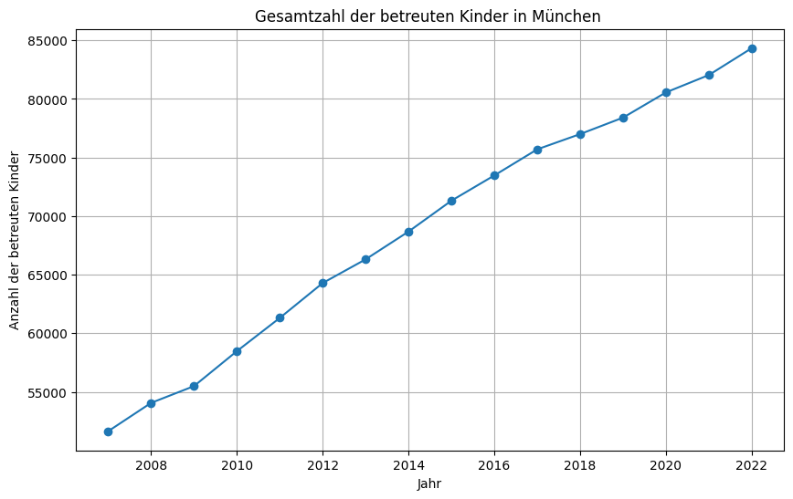

```python
df_filtered = df_altersgruppen[(df_altersgruppen['Raumbezug'] == 'Stadt München') &
                               (df_altersgruppen['Ausprägung'] == 'bis 2 Jahre')]
#df_filtered

# Line Plot erstellen

plt.figure(figsize=(10, 6)) # Größe des Plots
plt.plot(df_filtered['Jahr'], df_filtered['Basiswert.2'], marker='o') # Daten Auswählen
plt.title('Gesamtzahl der betreuten Kinder in München ') # Titel
plt.xlabel('Jahr') # x-Achse
plt.ylabel('Anzahl der betreuten Kinder') # y-Achse
plt.grid(True) # Gitternetzlinien
plt.show() # Plot anzeigen
```

Aus der Grafik lässt sich ein kontinuierlicher Anstieg der Gesamtzahl der betreuten Kinder in München über den Zeitraum von 2007 bis 2022 erkennen. Im Jahr 2007 lag die Zahl der betreuten Kinder bei etwa 52.000, während sie im Jahr 2022 auf ungefähr 85.000 anstieg. Dies zeigt eine signifikante Zunahme von etwa 33.000 betreuten Kindern innerhalb von 15 Jahren.

## Anzahl der betreuten Kinder im Laufe der Jahre, deren Familiensprache nicht Deutsch ist

Die Gesamtanzahl der betreuten Kinder in München, deren Familiensprache nicht Deutsch ist, wird in der Spalte “Basiswert.1” angegeben, wenn der Raumbezug “Stadt München” lautet. Der Datensatz df_altersgruppen_nichtdeutsch wurde gefiltert, um nur die Zeilen zu erhalten, bei denen der Raumbezug “Stadt München” ist. Dies stellt sicher, dass wir nur die relevanten Daten für München betrachten. Die gefilterten Daten wurden nach Jahr gruppiert, und die Anzahl der betreuten Kinder wurde summiert. Dies gibt uns die jährliche Gesamtanzahl der betreuten Kinder, deren Familiensprache nicht Deutsch ist.

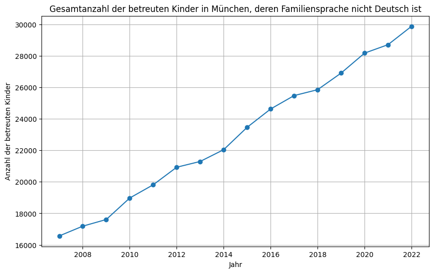

```python
# Filtern der Daten für die Stadt München
df_munich = df_altersgruppen_nichtdeutsch[df_altersgruppen_nichtdeutsch['Raumbezug'] == 'Stadt München']

# Gruppieren der Daten nach Jahr und Summieren der Anzahl der betreuten Kinder
total_betreute_kinder_munich = df_munich.groupby('Jahr')['Basiswert.1'].sum()

# Line Plot erstellen
plt.figure(figsize=(10, 6))
plt.plot(total_betreute_kinder_munich.index, total_betreute_kinder_munich.values, marker='o')
plt.title('Gesamtanzahl der betreuten Kinder in München, deren Familiensprache nicht Deutsch ist')
plt.xlabel('Jahr')
plt.ylabel('Anzahl der betreuten Kinder')
plt.grid(True)
plt.show()
```

## Anteil an betreuten Kinder im Laufe der Jahre, deren Familiensprache nicht Deutsch ist

Der Anteil der betreuten Kinder, deren Familiensprache nicht Deutsch ist, ist in unserem Dataframe auf drei Alterskategorien verteilt: 3 bis 7 Jahre (ohne Schulkinder), 5 bis 13 Jahre (Schulkinder), und bis 2 Jahre. Um den Gesamtanteil zu ermitteln, müssen die Zahlen dieser Kategorien summiert werden.

```python
# Erstellen eines Dataframes, dass die Anzahl der betreuten Kinder in München, deren Familiensprache nicht Deutsch ist, enthält
df_munich_kinder = pd.DataFrame(list(total_betreute_kinder_munich.items()), columns=['Jahr', 'nicht Deutsch'])

# Umkehren der Reihenfolge der Werte in der Spalte 'Basiswert.2'
basiswert_2_reversed = df_filtered['Basiswert.2'][::-1].reset_index(drop=True)

# Hinzufügen der umgekehrten Werte in das Dataframe
df_munich_kinder['Gesamtanzahl'] = basiswert_2_reversed

# Berechnung des prozentualen Anteils der betreuten Kinder, deren Familiensprache nicht Deutsch ist
df_munich_kinder['Prozentualer Anteil nicht Deutsch'] = round((df_munich_kinder['nicht Deutsch'] / df_munich_kinder['Gesamtanzahl']) * 100,1)

df_munich_kinder
```

|  | Jahr | nicht Deutsch | Gesamtanzahl | Prozentualer Anteil nicht Deutsch |
| --- | --- | --- | --- | --- |
| 0 | 2007 | 16565 | 51643 | 32.1 |
| 1 | 2008 | 17185 | 54061 | 31.8 |
| 2 | 2009 | 17607 | 55493 | 31.7 |
| 3 | 2010 | 18972 | 58476 | 32.4 |
| 4 | 2011 | 19813 | 61312 | 32.3 |
| 5 | 2012 | 20928 | 64288 | 32.6 |
| 6 | 2013 | 21295 | 66309 | 32.1 |
| 7 | 2014 | 22043 | 68679 | 32.1 |
| 8 | 2015 | 23464 | 71315 | 32.9 |
| 9 | 2016 | 24627 | 73470 | 33.5 |
| 10 | 2017 | 25479 | 75697 | 33.7 |
| 11 | 2018 | 25853 | 76998 | 33.6 |
| 12 | 2019 | 26907 | 78403 | 34.3 |
| 13 | 2020 | 28176 | 80555 | 35.0 |
| 14 | 2021 | 28713 | 82038 | 35.0 |
| 15 | 2022 | 29879 | 84333 | 35.4 |

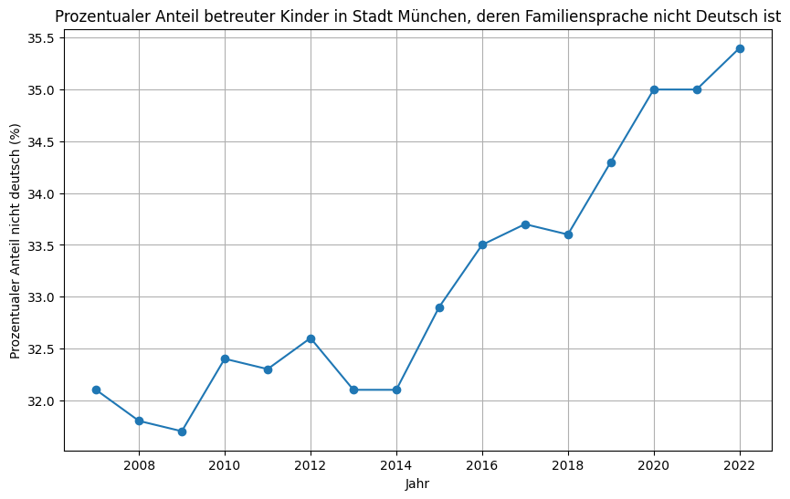

```python
plt.figure(figsize=(10, 6))
plt.plot(df_munich_kinder['Jahr'], df_munich_kinder['Prozentualer Anteil nicht Deutsch'], marker='o')
plt.title('Prozentualer Anteil betreuter Kinder in Stadt München, deren Familiensprache nicht Deutsch ist')
plt.xlabel('Jahr')
plt.ylabel('Prozentualer Anteil nicht deutsch (%)')
plt.grid(True)
plt.show()
```

### **Weitere Maßnahme zum Testen der Arbeitshypothese**

Wir untersuchen, ob der Anstieg der deutschen und nicht-deutschen Kinder mit Migrationshintergrund in München mit dem prozentualen Anstieg der Kinder in Kinderbetreuungseinrichtungen übereinstimmt, deren Familiensprache nicht Deutsch ist.

## Annahmen zur Analyse

Um eine fundierte Analyse durchzuführen, sind bestimmte Annahmen erforderlich.

1. **Hauptwohnsitzbevölkerung (deutsch und nichtdeutsch) (bis 17 Jahre):**
   - Diese Datenpunkte repräsentieren die Gesamtanzahl der Kinder in München, die potenziell eine Betreuungsstätte besuchen könnten.
2. **Hauptwohnsitzbevölkerung (mit Migrationshintergrund) (deutsch und nichtdeutsch) (bis 17 Jahre):**
   - Diese Datenpunkte repräsentieren die Anzahl der Kinder mit Migrationshintergrund in München, die potenziell eine Betreuungsstätte besuchen könnten.

Wir gehen davon aus, dass der Migrationshintergrund ein Indikator dafür ist, dass die Familiensprache nicht Deutsch ist.

## Gesamtzahl der Kinder in München

```python
# Filtern der Daten für die Stadt München, wo die Kinder deutscher und nichtdeutscher Herkunft sind
data_kinder_migration_muenchen = df_migrationshintergrund_kinder[(df_migrationshintergrund_kinder['Ausprägung'] == 'deutsch und nichtdeutsch') &
                             (df_migrationshintergrund_kinder['Raumbezug'] == 'Stadt München')]
data_kinder_migration_muenchen
```

|  | Indikator | Ausprägung | Jahr | Raumbezug | Indikatorwert | Basiswert.1 | Basiswert.2 | Name.Basiswert.1 | Name.Basiswert.2 |
| --- | --- | --- | --- | --- | --- | --- | --- | --- | --- |
| 832 | Migrationshintergrund Kinder | deutsch und nichtdeutsch | 2022 | Stadt München | 62.6 | 154544 | 247042 | Hauptwohnsitzbevölkerung (mit Migrationshinter... | Hauptwohnsitzbevölkerung (deutsch und nichtdeu... |
| 858 | Migrationshintergrund Kinder | deutsch und nichtdeutsch | 2021 | Stadt München | 61.8 | 149166 | 241232 | Hauptwohnsitzbevölkerung (mit Migrationshinter... | Hauptwohnsitzbevölkerung (deutsch und nichtdeu... |
| 884 | Migrationshintergrund Kinder | deutsch und nichtdeutsch | 2020 | Stadt München | 61.4 | 146672 | 238912 | Hauptwohnsitzbevölkerung (mit Migrationshinter... | Hauptwohnsitzbevölkerung (deutsch und nichtdeu... |
| 910 | Migrationshintergrund Kinder | deutsch und nichtdeutsch | 2019 | Stadt München | 61.0 | 144432 | 236921 | Hauptwohnsitzbevölkerung (mit Migrationshinter... | Hauptwohnsitzbevölkerung (deutsch und nichtdeu... |
| 936 | Migrationshintergrund Kinder | deutsch und nichtdeutsch | 2018 | Stadt München | 60.0 | 140114 | 233354 | Hauptwohnsitzbevölkerung (mit Migrationshinter... | Hauptwohnsitzbevölkerung (deutsch und nichtdeu... |
| 962 | Migrationshintergrund Kinder | deutsch und nichtdeutsch | 2017 | Stadt München | 58.9 | 135539 | 230018 | Hauptwohnsitzbevölkerung (mit Migrationshinter... | Hauptwohnsitzbevölkerung (deutsch und nichtdeu... |
| 988 | Migrationshintergrund Kinder | deutsch und nichtdeutsch | 2016 | Stadt München | 58.1 | 132237 | 227597 | Hauptwohnsitzbevölkerung (mit Migrationshinter... | Hauptwohnsitzbevölkerung (deutsch und nichtdeu... |
| 1014 | Migrationshintergrund Kinder | deutsch und nichtdeutsch | 2014 | Stadt München | 56.8 | 122796 | 216263 | Hauptwohnsitzbevölkerung (mit Migrationshinter... | Hauptwohnsitzbevölkerung (deutsch und nichtdeu... |
| 1040 | Migrationshintergrund Kinder | deutsch und nichtdeutsch | 2013 | Stadt München | 55.7 | 117461 | 211063 | Hauptwohnsitzbevölkerung (mit Migrationshinter... | Hauptwohnsitzbevölkerung (deutsch und nichtdeu... |
| 1066 | Migrationshintergrund Kinder | deutsch und nichtdeutsch | 2012 | Stadt München | 54.7 | 112981 | 206449 | Hauptwohnsitzbevölkerung (mit Migrationshinter... | Hauptwohnsitzbevölkerung (deutsch und nichtdeu... |
| 1092 | Migrationshintergrund Kinder | deutsch und nichtdeutsch | 2011 | Stadt München | 53.9 | 109076 | 202501 | Hauptwohnsitzbevölkerung (mit Migrationshinter... | Hauptwohnsitzbevölkerung (deutsch und nichtdeu... |
| 1118 | Migrationshintergrund Kinder | deutsch und nichtdeutsch | 2010 | Stadt München | 53.1 | 105225 | 198242 | Hauptwohnsitzbevölkerung (mit Migrationshinter... | Hauptwohnsitzbevölkerung (deutsch und nichtdeu... |
| 1144 | Migrationshintergrund Kinder | deutsch und nichtdeutsch | 2009 | Stadt München | 52.3 | 101768 | 194514 | Hauptwohnsitzbevölkerung (mit Migrationshinter... | Hauptwohnsitzbevölkerung (deutsch und nichtdeu... |
| 1170 | Migrationshintergrund Kinder | deutsch und nichtdeutsch | 2008 | Stadt München | 51.2 | 98991 | 193268 | Hauptwohnsitzbevölkerung (mit Migrationshinter... | Hauptwohnsitzbevölkerung (deutsch und nichtdeu... |
| 1196 | Migrationshintergrund Kinder | deutsch und nichtdeutsch | 2007 | Stadt München | 50.6 | 97015 | 191745 | Hauptwohnsitzbevölkerung (mit Migrationshinter... | Hauptwohnsitzbevölkerung (deutsch und nichtdeu... |
| 1222 | Migrationshintergrund Kinder | deutsch und nichtdeutsch | 2006 | Stadt München | 49.9 | 94136 | 188586 | Hauptwohnsitzbevölkerung (mit Migrationshinter... | Hauptwohnsitzbevölkerung (deutsch und nichtdeu... |

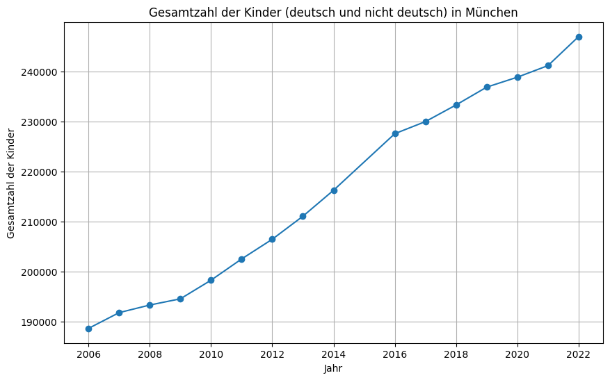

```python
plt.figure(figsize=(10, 6))
plt.plot(data_kinder_migration_muenchen['Jahr'], data_kinder_migration_muenchen['Basiswert.2'], marker='o')
plt.title('Gesamtzahl der Kinder (deutsch und nicht deutsch) in München')
plt.xlabel('Jahr')
plt.ylabel('Gesamtzahl der Kinder')
plt.grid(True)
plt.show()
```

Die Graphik zeigt die Gesamtzahl der Kinder (deutsche und nichtdeutsche) in München von 2006 bis 2022. Die Anzahl der Kinder steigt kontinuierlich von unter 190.000 im Jahr 2006 auf über 240.000 im Jahr 2022. Es gibt einen klaren Aufwärtstrend in der Anzahl der Kinder in München.

### Gesamtzahl der Kinder mit Migrationshintergrund in München, deren Familiensprache nicht Deutsch ist

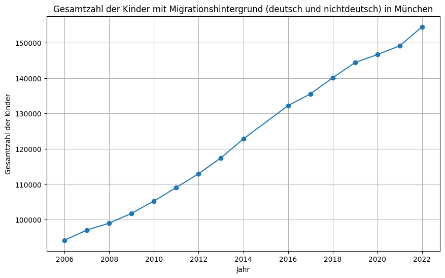

```python
plt.figure(figsize=(10, 6))
plt.plot(data_kinder_migration_muenchen['Jahr'], data_kinder_migration_muenchen['Basiswert.1'], marker='o')
plt.title('Gesamtzahl der Kinder mit Migrationshintergrund (deutsch und nichtdeutsch) in München')
plt.xlabel('Jahr')
plt.ylabel('Gesamtzahl der Kinder')
plt.grid(True)
plt.show()
```

Die Abbildung zeigt die Entwicklung der Gesamtzahl der Kinder mit Migrationshintergrund (deutsch und nichtdeutsch) in München von 2006 bis 2022. Es gibt einen stetigen Aufwärtstrend in der Anzahl der Kinder mit Migrationshintergrund.

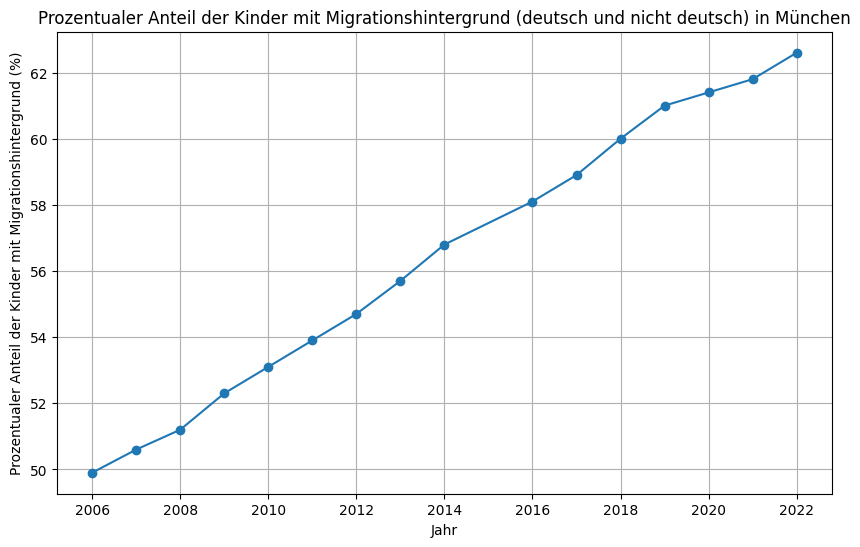

```python
plt.figure(figsize=(10, 6))
plt.plot(data_kinder_migration_muenchen['Jahr'], data_kinder_migration_muenchen['Indikatorwert'], marker='o')
plt.title('Prozentualer Anteil der Kinder mit Migrationshintergrund (deutsch und nicht deutsch) in München')
plt.xlabel('Jahr')
plt.ylabel('Prozentualer Anteil der Kinder mit Migrationshintergrund (%)')
plt.grid(True)
plt.show()
```

### **Fazit zu den Abbildungen im Bezug zur Arbeitshypothese**

Die beiden Abbildungen verdeutlichen, dass die Kinderbetreuung in München nicht das demografische Bild der Bevölkerung widerspiegelt. Der Anteil der Kinder mit Migrationshintergrund ist erheblich höher als der Anteil der betreuten Kinder, deren Familiensprache nicht Deutsch ist. Konkret ist der Anteil der Kinder mit Migrationshintergrund über die Jahre stetig gestiegen und liegt im Jahr 2022 bei über 62%. Im Gegensatz dazu liegt der Anteil der betreuten Kinder, deren Familiensprache nicht Deutsch ist, bei etwas über 35% im Jahr 2022.

Diese Diskrepanz zeigt, dass Kinder, deren Familiensprache nicht Deutsch ist, deutlich unterrepräsentiert in Betreuungseinrichtungen sind. Dies unterstützt die Arbeitshypothese, dass nicht-deutsche Kinder einen eingeschränkten Zugang zu Kinderbetreuung haben, was zur Ungleichheit beiträgt und die Ziele des Sustainable Development Goal (SDG) 10 zur Reduzierung von Ungleichheiten behindert. Trotz der jüngsten Verbesserungen bleibt weiterhin Handlungsbedarf, um sicherzustellen, dass alle Kinder, unabhängig von ihrem sprachlichen Hintergrund, gleichberechtigten Zugang zu Betreuungsangeboten erhalten und so die demografische Realität besser widergespiegelt wird.

Folgende Quellen beweisen eine richtige Interpretation der Datensätze: [5][6][7][8]

# Aufgabe 4 Ausreißeranalyse

### Analyse der Daten auf Ausreißer

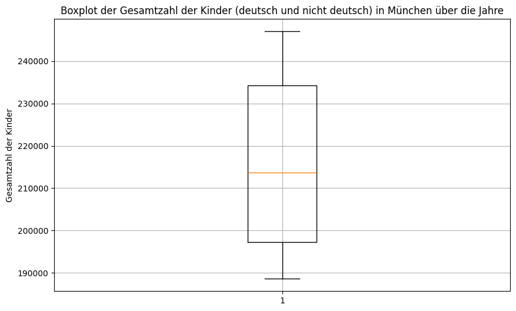

```python
# Boxplot der Gesamtzahl der Kinder (deutsch und nicht deutsch) in München
gesamtzahl_kinder = data_kinder_migration_muenchen['Basiswert.2']
plt.figure(figsize=(10, 6))
plt.boxplot(gesamtzahl_kinder) # Boxplot
plt.title('Boxplot der Gesamtzahl der Kinder (deutsch und nicht deutsch) in München über die Jahre')
plt.ylabel('Gesamtzahl der Kinder')
plt.grid(True)
plt.show()
```

```python
gesamtzahl_kinder.describe()
```

```
count        16.000000
mean     216106.687500
std       20209.470142
min      188586.000000
25%      197310.000000
50%      213663.000000
75%      234245.750000
max      247042.000000
Name: Basiswert.2, dtype: float64
```

### Schlussfolgerung

Die statistische Zusammenfassung der Daten bestätigt, dass die Gesamtzahl der Kinder (deutsch und nicht deutsch) in München über die Jahre einen kontinuierlichen und gleichmäßigen Anstieg zeigt. Es gibt keine signifikanten Ausreißer, die die Verteilung der Daten verzerren könnten. Dies wird durch den nah beieinander liegenden Mittelwert und Median, die angemessene Standardabweichung und die gleichmäßige Verteilung innerhalb des Interquartilsabstandes unterstrichen.

### Warum können extreme Beobachtungen problematisch sein?

- **Verzerrung der Ergebnisse:** Ausreißer können statistische Kennzahlen wie Mittelwert und Standardabweichung stark beeinflussen, was zu einer verzerrten Interpretation der Daten führt.
- **Modellannahmen verletzen:** Viele statistische Modelle setzen eine Normalverteilung der Daten voraus. Ausreißer können diese Annahme verletzen und die Modellgüte beeinträchtigen.
- **Irreführende Schlussfolgerungen:** Entscheidungen, die auf analysierten Daten basieren, können fehlerhaft sein, wenn diese Daten durch Ausreißer verzerrt sind.

### Ansatz zum Handling von Ausreißern [9]

Clustering-Verfahren sind Methoden des unüberwachten Lernens (unsupervised learning), die genutzt werden, um Muster in Daten zu erkennen. Ein spezifischer Anwendungsfall von Clustering ist die Erkennung von Ausreißern.

1. **Erkennen von Clustern / Gruppen in den Daten:** Nutzen eines ein Clustering-Verfahrens, um Gruppen oder Cluster in den Daten zu identifizieren.
2. **Bestimmen von Distanzen der Beobachtungen zu den Cluster(-zentren):** Berechnen der Distanzen der einzelnen Datenpunkte zu den Zentren ihrer zugehörigen Cluster.
3. **Kategorisierung extrem “weit” entfernter Beobachtungen als Ausreißer:** Identifizieren der Beobachtungen, die weit von ihren Clusterzentren entfernt sind, und kategorisieren Sie diese als Ausreißer.

#### Beispiel Visualisierung:

- Die blauen Punkte stellen normale Datenpunkte dar, die in Clustern gruppiert sind.
- Die orangen Punkte stellen die Ausreißer dar, die weit von den Clustern entfernt sind.
- Die Kreise um die Cluster herum zeigen die Gruppierung der normalen Datenpunkte an.

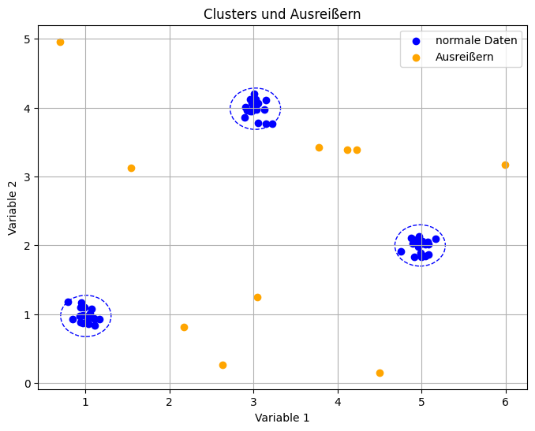

```python
# # Cluster 1
x1_c1 = np.random.normal(1, 0.1, 20)
x2_c1 = np.random.normal(1, 0.1, 20)

# Cluster 2
x1_c2 = np.random.normal(3, 0.1, 20)
x2_c2 = np.random.normal(4, 0.1, 20)

# Cluster 3
x1_c3 = np.random.normal(5, 0.1, 20)
x2_c3 = np.random.normal(2, 0.1, 20)

# Ausreißer
x1_noise = np.random.uniform(0, 6, 10)
x2_noise = np.random.uniform(0, 5, 10)

plt.figure(figsize=(8, 6))

# Plotten der Cluster
plt.scatter(x1_c1, x2_c1, color='blue', label='normale Daten')
plt.scatter(x1_c2, x2_c2, color='blue')
plt.scatter(x1_c3, x2_c3, color='blue')

# Kreise um die Clusterzentren
circles = [
    plt.Circle((np.mean(x1_c1), np.mean(x2_c1)), 0.3, color='blue', fill=False, linestyle='--'),
    plt.Circle((np.mean(x1_c2), np.mean(x2_c2)), 0.3, color='blue', fill=False, linestyle='--'),
    plt.Circle((np.mean(x1_c3), np.mean(x2_c3)), 0.3, color='blue', fill=False, linestyle='--')
]

# Hinzufügen der Kreise zum Plot
ax = plt.gca()
for circle in circles:
    ax.add_artist(circle)

# Plotten der Ausreißer
plt.scatter(x1_noise, x2_noise, color='orange', label='Ausreißern')

plt.xlabel('Variable 1')
plt.ylabel('Variable 2')
plt.legend()
plt.title('Clusters und Ausreißern')
plt.grid(True)

plt.show()
```

# Aufgabe 5 Anonymisierung

In meinen Datensätzen gibt es keine Probleme bezüglich der Anonymisierung, und es sind keine kritischen Variablen enthalten, die Rückschlüsse auf personenbezogene Daten zulassen würden.

### Beispiel für ein Problem mit der Anonymisierung

Angenommen, wir haben einen Datensatz, der die folgenden Variablen enthält:

- **Postleitzahl**
- **Beruf**

In diesem Beispiel könnten die Variablen **Postleitzahl** und **Beruf** in Kombination ein Risiko für die Anonymisierung darstellen. Ein seltener Beruf in einer kleinen Postleitzahlregion könnte es ermöglichen, eine Person eindeutig zu identifizieren, selbst wenn der Name der Person nicht direkt im Datensatz enthalten ist.

### Lösungsansatz zur Verbesserung der Anonymisierung

Ein möglicher Lösungsansatz zur Verbesserung der Anonymisierung könnte die Anwendung von **K-Anonymität** sein. K-Anonymität stellt sicher, dass jede Kombination von Quasi-Identifikatoren (wie Postleitzahl und Beruf) in mindestens $k$ Datensätzen vorkommt, um das Risiko der Rückverfolgbarkeit zu reduzieren. Dies könnte wie folgt erreicht werden:

1. **Generalisation**: Gruppieren der Daten in breitere Kategorien. Beispielsweise könnte die Postleitzahl auf die ersten zwei Ziffern reduziert werden, und Berufe könnten in allgemeinere Kategorien zusammengefasst werden (z.B. „Ingenieurwesen“ statt Chemieingenieur).

#### Beispiel

- Ursprünglich:
  - Postleitzahl: 12345
  - Beruf: Chemieingenieur
- Nach Generalisation:
  - Postleitzahl: 12***
  - Beruf: Ingenieurwesen

# Aufgaben 6 & 7 Info-Grafik

```python
# Gruppieren der Daten nach Jahr, Raumbezug (Stadtbezirke) und Summieren der relevanten Spalten
daten_aufsummiert = df_altersgruppen_nichtdeutsch.groupby(['Jahr', 'Raumbezug']).agg({
    'Basiswert.1': 'sum',
    'Basiswert.2': 'sum'
}).reset_index()

# Spalten umbenennen
daten_aufsummiert.rename(columns={
    'Basiswert.1': 'Gesamtzahl nichtdeutsche Familiensprache',
    'Basiswert.2': 'Gesamtzahl betreute Kinder'
}, inplace=True)

# Runden auf eine Dezimalstelle
daten_aufsummiert['Indikatorwert'] = round((daten_aufsummiert['Gesamtzahl nichtdeutsche Familiensprache'] / daten_aufsummiert['Gesamtzahl betreute Kinder']) * 100,1)


daten_aufsummiert
```

|  | Jahr | Raumbezug | Gesamtzahl nichtdeutsche Familiensprache | Gesamtzahl betreute Kinder | Indikatorwert |
| --- | --- | --- | --- | --- | --- |
| 0 | 2007 | 01 Altstadt - Lehel | 159 | 815 | 19.5 |
| 1 | 2007 | 02 Ludwigsvorstadt - Isarvorstadt | 556 | 1733 | 32.1 |
| 2 | 2007 | 03 Maxvorstadt | 463 | 1875 | 24.7 |
| 3 | 2007 | 04 Schwabing - West | 330 | 1238 | 26.7 |
| 4 | 2007 | 05 Au - Haidhausen | 670 | 2441 | 27.4 |
| ... | ... | ... | ... | ... | ... |
| 411 | 2022 | 22 Aubing - Lochhausen - Langwied | 1473 | 3477 | 42.4 |
| 412 | 2022 | 23 Allach - Untermenzing | 422 | 1816 | 23.2 |
| 413 | 2022 | 24 Feldmoching - Hasenbergl | 1737 | 3434 | 50.6 |
| 414 | 2022 | 25 Laim | 842 | 2450 | 34.4 |
| 415 | 2022 | Stadt München | 29879 | 84333 | 35.4 |

416 rows × 5 columns

```python
# Filtern der Daten für deutsche und nichtdeutsche Kinder
daten_kinder_migration = df_migrationshintergrund_kinder[(df_migrationshintergrund_kinder['Ausprägung'] == 'deutsch und nichtdeutsch')]
daten_kinder_migration
```

|  | Indikator | Ausprägung | Jahr | Raumbezug | Indikatorwert | Basiswert.1 | Basiswert.2 | Name.Basiswert.1 | Name.Basiswert.2 |
| --- | --- | --- | --- | --- | --- | --- | --- | --- | --- |
| 832 | Migrationshintergrund Kinder | deutsch und nichtdeutsch | 2022 | Stadt München | 62.6 | 154544 | 247042 | Hauptwohnsitzbevölkerung (mit Migrationshinter... | Hauptwohnsitzbevölkerung (deutsch und nichtdeu... |
| 833 | Migrationshintergrund Kinder | deutsch und nichtdeutsch | 2022 | 01 Altstadt - Lehel | 52.1 | 1317 | 2527 | Hauptwohnsitzbevölkerung (mit Migrationshinter... | Hauptwohnsitzbevölkerung (deutsch und nichtdeu... |
| 834 | Migrationshintergrund Kinder | deutsch und nichtdeutsch | 2022 | 02 Ludwigsvorstadt - Isarvorstadt | 49.7 | 2985 | 6010 | Hauptwohnsitzbevölkerung (mit Migrationshinter... | Hauptwohnsitzbevölkerung (deutsch und nichtdeu... |
| 835 | Migrationshintergrund Kinder | deutsch und nichtdeutsch | 2022 | 03 Maxvorstadt | 57.7 | 3189 | 5523 | Hauptwohnsitzbevölkerung (mit Migrationshinter... | Hauptwohnsitzbevölkerung (deutsch und nichtdeu... |
| 836 | Migrationshintergrund Kinder | deutsch und nichtdeutsch | 2022 | 04 Schwabing - West | 52.1 | 4529 | 8685 | Hauptwohnsitzbevölkerung (mit Migrationshinter... | Hauptwohnsitzbevölkerung (deutsch und nichtdeu... |
| ... | ... | ... | ... | ... | ... | ... | ... | ... | ... |
| 1243 | Migrationshintergrund Kinder | deutsch und nichtdeutsch | 2006 | 21 Pasing - Obermenzing | 36.5 | 3795 | 10395 | Hauptwohnsitzbevölkerung (mit Migrationshinter... | Hauptwohnsitzbevölkerung (deutsch und nichtdeu... |
| 1244 | Migrationshintergrund Kinder | deutsch und nichtdeutsch | 2006 | 22 Aubing - Lochhausen - Langwied | 48.2 | 3170 | 6576 | Hauptwohnsitzbevölkerung (mit Migrationshinter... | Hauptwohnsitzbevölkerung (deutsch und nichtdeu... |
| 1245 | Migrationshintergrund Kinder | deutsch und nichtdeutsch | 2006 | 23 Allach - Untermenzing | 31.6 | 1496 | 4737 | Hauptwohnsitzbevölkerung (mit Migrationshinter... | Hauptwohnsitzbevölkerung (deutsch und nichtdeu... |
| 1246 | Migrationshintergrund Kinder | deutsch und nichtdeutsch | 2006 | 24 Feldmoching - Hasenbergl | 55.7 | 5524 | 9917 | Hauptwohnsitzbevölkerung (mit Migrationshinter... | Hauptwohnsitzbevölkerung (deutsch und nichtdeu... |
| 1247 | Migrationshintergrund Kinder | deutsch und nichtdeutsch | 2006 | 25 Laim | 50.8 | 3123 | 6152 | Hauptwohnsitzbevölkerung (mit Migrationshinter... | Hauptwohnsitzbevölkerung (deutsch und nichtdeu... |

416 rows × 9 columns

```python
# Filtern der Daten für den ersten Stadtbezirk
initial_stadtbezirk = daten_aufsummiert['Raumbezug'].unique()[0]
daten_aufsummiert_filtered = daten_aufsummiert[daten_aufsummiert['Raumbezug'] == initial_stadtbezirk]
daten_kinder_migration_filtered = daten_kinder_migration[daten_kinder_migration['Raumbezug'] == initial_stadtbezirk]

# go.FigureWidget() erstellt eine interaktive Figur
fig = go.FigureWidget()

# Hinzufügen der Linie für die Daten
fig.add_trace(go.Scatter( # go.Scatter() erstellt einen Linienplot
    x=daten_aufsummiert_filtered['Jahr'], # x-Achse
    y=daten_aufsummiert_filtered['Indikatorwert'], # y-Achse
    mode='lines', # Linienplot
    name='Anteil an Kinder mit nichtdeutscher Familiensprache auf die Gesamtanzahl der betreuten Kinder',
    line=dict(color='blue') # Farbe der Linie
))

# Hinzufügen der Linie für die Daten
fig.add_trace(go.Scatter(
    x=daten_kinder_migration_filtered['Jahr'],
    y=daten_kinder_migration_filtered['Indikatorwert'],
    mode='lines',
    name='Anteil an Kinder mit Migrationshintergrund auf die Gesamtanzahl der Kinder',
    line=dict(color='red')
))

# Anpassung der Layouteigenschaften
fig.update_layout(
    title=f'Anteil über die Jahre für {initial_stadtbezirk}', # Titel Anpassung für den Stadtbezirk
    xaxis_title='Jahr',
    yaxis_title='Anteil in %',
    legend_title='Legende'
)

# Funktion zur Aktualisierung der Figur
def update_figure(stadtbezirk):
    daten_aufsummiert_filtered = daten_aufsummiert[daten_aufsummiert['Raumbezug'] == stadtbezirk]
    daten_kinder_migration_filtered = daten_kinder_migration[daten_kinder_migration['Raumbezug'] == stadtbezirk]

    with fig.batch_update(): # Aktualisierung der Figur
        fig.data[0].x = daten_aufsummiert_filtered['Jahr']
        fig.data[0].y = daten_aufsummiert_filtered['Indikatorwert']

        fig.data[1].x = daten_kinder_migration_filtered['Jahr']
        fig.data[1].y = daten_kinder_migration_filtered['Indikatorwert']

        fig.layout.title.text = f'Anteil über die Jahre für {stadtbezirk}' # Titel Anpassung für den Stadtbezirk

# Interaktive Auswahl des Stadtbezirks
stadtbezirk_selector = widgets.Dropdown(
    options=daten_aufsummiert['Raumbezug'].unique(), # Auswahlmöglichkeiten für den Stadtbezirk
    description='Stadtbezirk:',
    disabled=False, # Deaktivierung nicht möglich
)

# Funktion zur Aktualisierung der Figur bei einer Änderung der Auswahl
def on_value_change(change):
    update_figure(change['new']) # change['new'] gibt den neuen Wert der Auswahl zurück

stadtbezirk_selector.observe(on_value_change, names='value') # Beobachtung der Änderung der Auswahl

# Anzeige des Widgets und der Figur in der gleichen Zelle
display(stadtbezirk_selector)
display(fig)
```

```
Dropdown(description='Stadtbezirk:', options=('01 Altstadt - Lehel', '02 Ludwigsvorstadt - Isarvorstadt', '03 …
```

```
FigureWidget({
    'data': [{'line': {'color': 'blue'},
              'mode': 'lines',
              'name': ('Anteil an Kinder mit nichtdeut' ... 'amtanzahl der betreuten Kinder'),
              'type': 'scatter',
              'uid': 'aa390caf-8071-431e-8a8d-0d073fbf17b9',
              'x': array([2007, 2008, 2009, 2010, 2011, 2012, 2013, 2014, 2015, 2016, 2017, 2018,
                          2019, 2020, 2021, 2022]),
              'y': array([19.5, 21.3, 20. , 20.6, 19.9, 17.6, 20.3, 18.2, 17. , 19.7, 24.1, 20.7,
                          21.1, 20.5, 21.1, 20.3])},
             {'line': {'color': 'red'},
              'mode': 'lines',
              'name': 'Anteil an Kinder mit Migrationshintergrund auf die Gesamtanzahl der Kinder',
              'type': 'scatter',
              'uid': '97b98b2e-4b45-407a-ae4c-9a12542d74c1',
              'x': array([2022, 2021, 2020, 2019, 2018, 2017, 2016, 2014, 2013, 2012, 2011, 2010,
                          2009, 2008, 2007, 2006]),
              'y': array([52.1, 50.8, 50.4, 51.4, 49.8, 49.2, 47.9, 46.3, 45.1, 43.8, 41.8, 41.7,
                          41. , 41.6, 41.6, 41.2])}],
    'layout': {'legend': {'title': {'text': 'Legende'}},
               'template': '...',
               'title': {'text': 'Anteil über die Jahre für 01 Altstadt - Lehel'},
               'xaxis': {'title': {'text': 'Jahr'}},
               'yaxis': {'title': {'text': 'Anteil in %'}}}
})
```

Die erstellten Info-Grafiken verdeutlichen, dass die Kinderbetreuung in München nicht das demografische Bild der Bevölkerung widerspiegelt. Über alle Stadtbezirke hinweg zeigt sich eine signifikante Diskrepanz zwischen dem Anteil der Kinder mit Migrationshintergrund und dem Anteil der betreuten Kinder, deren Familiensprache nicht Deutsch ist.

### Beobachtungen:

1. **Steigender Anteil von Kindern mit Migrationshintergrund**:
   - Der Anteil der Kinder mit Migrationshintergrund ist über die Jahre in fast allen Stadtbezirken kontinuierlich gestiegen.
   - Im Jahr 2022 liegt dieser Anteil in vielen Stadtbezirken bei über 60%.
2. **Geringerer Anteil von betreuten Kindern mit nichtdeutscher Familiensprache**:
   - Im Vergleich dazu ist der Anteil der betreuten Kinder, deren Familiensprache nicht Deutsch ist, wesentlich geringer.
   - In den meisten Stadtbezirken liegt dieser Anteil im Jahr 2022 bei etwa 30-40%.

### Diskrepanz:

Die erstellten Info-Grafiken verdeutlichen, dass die Kinderbetreuung in München nicht das demografische Bild der Bevölkerung widerspiegelt. Über alle Stadtbezirke hinweg zeigt sich eine signifikante Diskrepanz zwischen dem Anteil der Kinder mit Migrationshintergrund und dem Anteil der betreuten Kinder, deren Familiensprache nicht Deutsch ist.

### Unterstützung der Arbeitshypothese:

Diese Diskrepanz stützt die Arbeitshypothese, dass Kinder, deren Familiensprache nicht Deutsch ist, eingeschränkten Zugang zu Kinderbetreuungseinrichtungen haben. Dies trägt zur Ungleichheit bei und behindert die Erreichung des Sustainable Development Goal (SDG) 10, das darauf abzielt, Ungleichheiten zu reduzieren.

# Quellen

```python
bibfile = "A&V.bib"

def clean_latex_formatting(text):
    text = re.sub(r"(\{|\})", "", text)
    return text

def format_ieee(entry, entry_number):
    # Title bereinigen
    title = clean_latex_formatting(entry.fields.get('title', '[Title not found]'))

    # Autorenliste erstellen, falls vorhanden
    authors = entry.persons.get('author', None)
    if authors:
        authors = ' and '.join(' '.join(p.first_names + p.last_names) for p in authors)
    else:
        authors = title  # Use title if author is not available

    year = entry.fields.get('year', '[Year not found]')
    url = entry.fields.get('url', '')

    # Formatieren basierend auf dem Eintragstyp
    if 'booktitle' in entry.fields:  # for conference papers
        booktitle = clean_latex_formatting(entry.fields.get('booktitle'))
        citation = f"[{entry_number}] {authors}, \"{title},\" in {booktitle}, {year}."
    if 'wikipedia.org' in url:
        # Formatting Wikipedia-specific reference
        citation = f"[{entry_number}] \"{title},\" Wikipedia, {year}. [Online]. Available: {url}."
    elif 'journal' in entry.fields:  # for journal articles
        journal = clean_latex_formatting(entry.fields.get('journal'))
        volume = entry.fields.get('volume', '[Volume not found]')
        number = entry.fields.get('number', '[Issue not found]')
        pages = entry.fields.get('pages', '[Pages not found]')
        citation = f"[{entry_number}] {authors}, \"{title},\" {journal}, vol. {volume}, no. {number}, pp. {pages}, {year}."
    elif entry.type == 'book':  # for books
        publisher = clean_latex_formatting(entry.fields.get('publisher', '[Publisher not found]'))
        citation = f"[{entry_number}] {authors}, {title}. {publisher}, {year}."
    else:  # for other types
        citation = f"[{entry_number}] {authors}, {title}, {year}."

    return citation

# BibTeX-Datei lesen
bib_data = parse_file(bibfile)

# Alle Einträge im IEEE-Stil konvertieren
ieee_references = [format_ieee(entry, i+1) for i, (key, entry) in enumerate(bib_data.entries.items())]

# Alle IEEE-Stil Zitate ausgeben
print("\033[1mQuellen\033[0m ")
print('')
for ref in ieee_references:
    print(ref)
    print('')
```

```
Quellen

[1] Goal 10 \textbar Department of Economic and Social Affairs, Goal 10 \textbar Department of Economic and Social Affairs, [Year not found].

[2] Indikatorenatlas: Bevölkerung - Migrationshintergrund - Kinder - Migrationshintergrund - Kinder - Open Data München, Indikatorenatlas: Bevölkerung - Migrationshintergrund - Kinder - Migrationshintergrund - Kinder - Open Data München, [Year not found].

[3] Indikatorenatlas: Kinderbetreuung - Altersgruppen - Open Data München, Indikatorenatlas: Kinderbetreuung - Altersgruppen - Open Data München, [Year not found].

[4] Indikatorenatlas: Kinderbetreuung - Altersgruppen Familiensprache nichtdeutsch - Open Data München, Indikatorenatlas: Kinderbetreuung - Altersgruppen Familiensprache nichtdeutsch - Open Data München, [Year not found].

[5] Landeshauptstadt München - Monatszahlen-Monitoring, Landeshauptstadt München - Monatszahlen-Monitoring, [Year not found].

[6] Landeshauptstadt München - Monatszahlen-Monitoring, Landeshauptstadt München - Monatszahlen-Monitoring, [Year not found].

[7] Landeshauptstadt München - Indikatorenatlas, Landeshauptstadt München - Indikatorenatlas, [Year not found].

[8] Dr Rzehak, Demografie der Münchner Bevölkerung 2020, 2021.

[9] Kurs: Datenaufbereitung und Visualisierung (Thiemichen) \textbar Moodle-Lernplattform, Kurs: Datenaufbereitung und Visualisierung (Thiemichen) \textbar Moodle-Lernplattform, [Year not found].
```

# Requirements Info

```python
original_stdout = sys.stdout  # Speichern des aktuellen Standardausgabe-Puffers
with open("DataViz_MA_Dervisevic_Dino_04299423_requirements.txt", "w") as f:
    sys.stdout = f  # Umleiten der Standardausgabe in die Datei
    sinfo()  # Aufrufen von sinfo und Ausgeben der Informationen in die Datei
    sys.stdout = original_stdout  # Wiederherstellen der Standardausgabe
```